[figure not shown]

# DATA SCIENTIST

**In this notebook, We review some basic skills of data science, neither more nor less.**

Data scientist need to have these skills:

1. Basic Tools: Like python, R or SQL. You do not need to know everything. Let's start with **python**. Remember, use a tool perfectly is more important than use the perfect tool. Nevertheless, some experience with SQL & RDBMS (relational database management systems) would be of great value.
2. Basic Statistics: Like mean, median or standart deviation. If you know basic statistics, you can use **python** easily. Moreover, a solid background in probability theory and statistics hypothesis testing will bring you to a higher level.
3. Data Wrangling: Working with messy and difficult data inclusing grouping, reshaping, transforming, cleaning data. As you guess, **python** helps us.
4. Data Visualization: We will visualize the data with **python** like matplot and seaborn libraries. Pandas itself is shifted with a lot of plotting features that run on top of matplotlib.
5. Machine Learning: think of it as a toolkit of advanced analytic algorithms. You need to understand basics of machine learning and learning how to implement it while using **python**.

```python
import numpy as np
import pandas as pd
import matplotlib.pyplot as plt
import seaborn as sns
%matplotlib inline
%matplotlib notebook
sns.set_style('whitegrid')
import warnings
warnings.filterwarnings("ignore")
```

```python
# use pandas to read pokemon.csv file to "data" dataframe and display first 5 rows
```

|  | # | Name | Type 1 | Type 2 | HP | Attack | Defense | Sp. Atk | Sp. Def | Speed | Generation | Legendary |
| --- | --- | --- | --- | --- | --- | --- | --- | --- | --- | --- | --- | --- |
| 0 | 1 | Bulbasaur | Grass | Poison | 45 | 49 | 49 | 65 | 65 | 45 | 1 | False |
| 1 | 2 | Ivysaur | Grass | Poison | 60 | 62 | 63 | 80 | 80 | 60 | 1 | False |
| 2 | 3 | Venusaur | Grass | Poison | 80 | 82 | 83 | 100 | 100 | 80 | 1 | False |
| 3 | 4 | Mega Venusaur | Grass | Poison | 80 | 100 | 123 | 122 | 120 | 80 | 1 | False |
| 4 | 5 | Charmander | Fire | NaN | 39 | 52 | 43 | 60 | 50 | 65 | 1 | False |

```python
# use pandas to show data's info
```

```
<class 'pandas.core.frame.DataFrame'>
RangeIndex: 800 entries, 0 to 799
Data columns (total 12 columns):
 #   Column      Non-Null Count  Dtype
---  ------      --------------  -----
 0   #           800 non-null    int64
 1   Name        799 non-null    object
 2   Type 1      800 non-null    object
 3   Type 2      414 non-null    object
 4   HP          800 non-null    int64
 5   Attack      800 non-null    int64
 6   Defense     800 non-null    int64
 7   Sp. Atk     800 non-null    int64
 8   Sp. Def     800 non-null    int64
 9   Speed       800 non-null    int64
 10  Generation  800 non-null    int64
 11  Legendary   800 non-null    bool
dtypes: bool(1), int64(8), object(3)
memory usage: 69.7+ KB
```

```python
# use pandas to show correlation of fields in data dataframe
```

|  | # | HP | Attack | Defense | Sp. Atk | Sp. Def | Speed | Generation | Legendary |
| --- | --- | --- | --- | --- | --- | --- | --- | --- | --- |
| # | 1.000000 | 0.097712 | 0.102664 | 0.094691 | 0.089199 | 0.085596 | 0.012181 | 0.983428 | 0.154336 |
| HP | 0.097712 | 1.000000 | 0.422386 | 0.239622 | 0.362380 | 0.378718 | 0.175952 | 0.058683 | 0.273620 |
| Attack | 0.102664 | 0.422386 | 1.000000 | 0.438687 | 0.396362 | 0.263990 | 0.381240 | 0.051451 | 0.345408 |
| Defense | 0.094691 | 0.239622 | 0.438687 | 1.000000 | 0.223549 | 0.510747 | 0.015227 | 0.042419 | 0.246377 |
| Sp. Atk | 0.089199 | 0.362380 | 0.396362 | 0.223549 | 1.000000 | 0.506121 | 0.473018 | 0.036437 | 0.448907 |
| Sp. Def | 0.085596 | 0.378718 | 0.263990 | 0.510747 | 0.506121 | 1.000000 | 0.259133 | 0.028486 | 0.363937 |
| Speed | 0.012181 | 0.175952 | 0.381240 | 0.015227 | 0.473018 | 0.259133 | 1.000000 | -0.023121 | 0.326715 |
| Generation | 0.983428 | 0.058683 | 0.051451 | 0.042419 | 0.036437 | 0.028486 | -0.023121 | 1.000000 | 0.079794 |
| Legendary | 0.154336 | 0.273620 | 0.345408 | 0.246377 | 0.448907 | 0.363937 | 0.326715 | 0.079794 | 1.000000 |

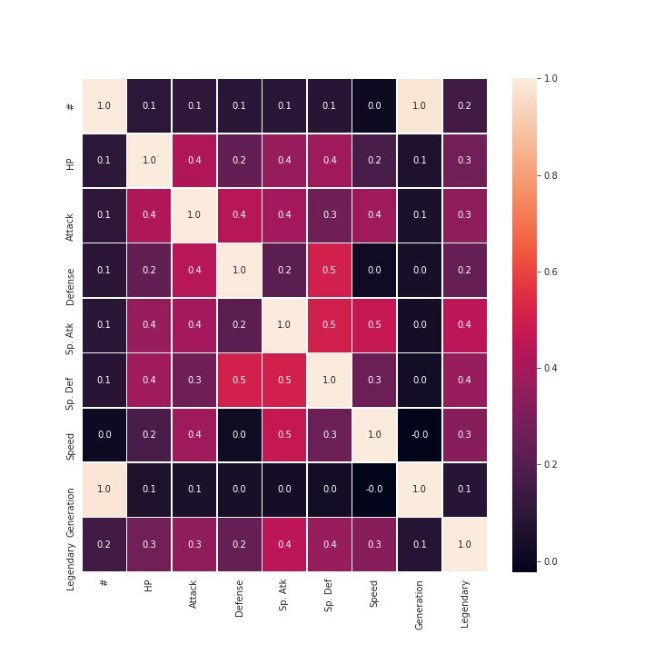

```python
# use seaborn's heatmap function to show correlation heatmap of the above correlation matrix
```

```python
# show columns list of data dataframe
```

```
Index(['#', 'Name', 'Type 1', 'Type 2', 'HP', 'Attack', 'Defense', 'Sp. Atk',
       'Sp. Def', 'Speed', 'Generation', 'Legendary'],
      dtype='object')
```

# 1. INTRODUCTION TO PYTHON

### MATPLOTLIB

Matplot is a python library that help us to plot data. The easiest and basic plots are line, scatter and histogram plots.

- Line plot is better when x axis is time.
- Scatter is better when there is correlation between two variables
- Histogram is better when we need to see distribution of numerical data.
- Customization: Colors,labels,thickness of line, title, opacity, grid, figsize, ticks of axis and linestyle

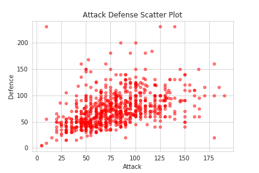

```python
# Scatter Plot
# use pandas' plot function to show the scatter plot between 'Attack' & 'Defense'
# don't forget to set xlabel, ylabel & title
```

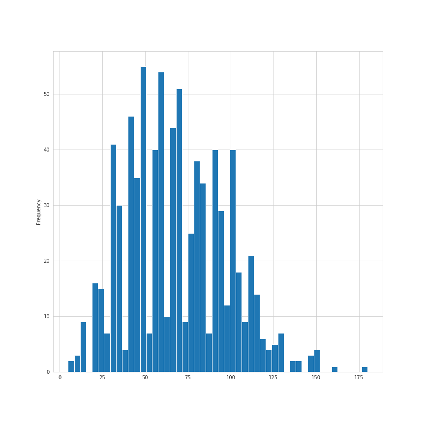

```python
# Histogram
# bins = number of bar in figure
# use pandas' plot function to show histogram for 'Speed' with 50 bins
```

```python
# show that data['Defense'] is a Series and data[['Defense']] is a dataframe
```

```
<class 'pandas.core.series.Series'>
<class 'pandas.core.frame.DataFrame'>
```

```python
# 1 - Filtering Pandas data frame
# who data's rows with Defense value > 200
```

|  | # | Name | Type 1 | Type 2 | HP | Attack | Defense | Sp. Atk | Sp. Def | Speed | Generation | Legendary |
| --- | --- | --- | --- | --- | --- | --- | --- | --- | --- | --- | --- | --- |
| 224 | 225 | Mega Steelix | Steel | Ground | 75 | 125 | 230 | 55 | 95 | 30 | 2 | False |
| 230 | 231 | Shuckle | Bug | Rock | 20 | 10 | 230 | 10 | 230 | 5 | 2 | False |
| 333 | 334 | Mega Aggron | Steel | NaN | 70 | 140 | 230 | 60 | 80 | 50 | 3 | False |

```python
# 2 - Filtering pandas with logical_and
# show pokemons who have higher defence value than 2oo and higher attack value than 100
```

|  | # | Name | Type 1 | Type 2 | HP | Attack | Defense | Sp. Atk | Sp. Def | Speed | Generation | Legendary |
| --- | --- | --- | --- | --- | --- | --- | --- | --- | --- | --- | --- | --- |
| 224 | 225 | Mega Steelix | Steel | Ground | 75 | 125 | 230 | 55 | 95 | 30 | 2 | False |
| 333 | 334 | Mega Aggron | Steel | NaN | 70 | 140 | 230 | 60 | 80 | 50 | 3 | False |

```python
# do you have another way to achieve the above cell?
# if not, skip this
```

|  | # | Name | Type 1 | Type 2 | HP | Attack | Defense | Sp. Atk | Sp. Def | Speed | Generation | Legendary |
| --- | --- | --- | --- | --- | --- | --- | --- | --- | --- | --- | --- | --- |
| 224 | 225 | Mega Steelix | Steel | Ground | 75 | 125 | 230 | 55 | 95 | 30 | 2 | False |
| 333 | 334 | Mega Aggron | Steel | NaN | 70 | 140 | 230 | 60 | 80 | 50 | 3 | False |

```python
# show data's shape (no. of columns & no. of rows)
```

```
(800, 12)
```